# Some things about me

Juliano Palacios Abrantes - http://www.laff.bren.ucsb.edu/laff-network/juliano-palacios-abrantes

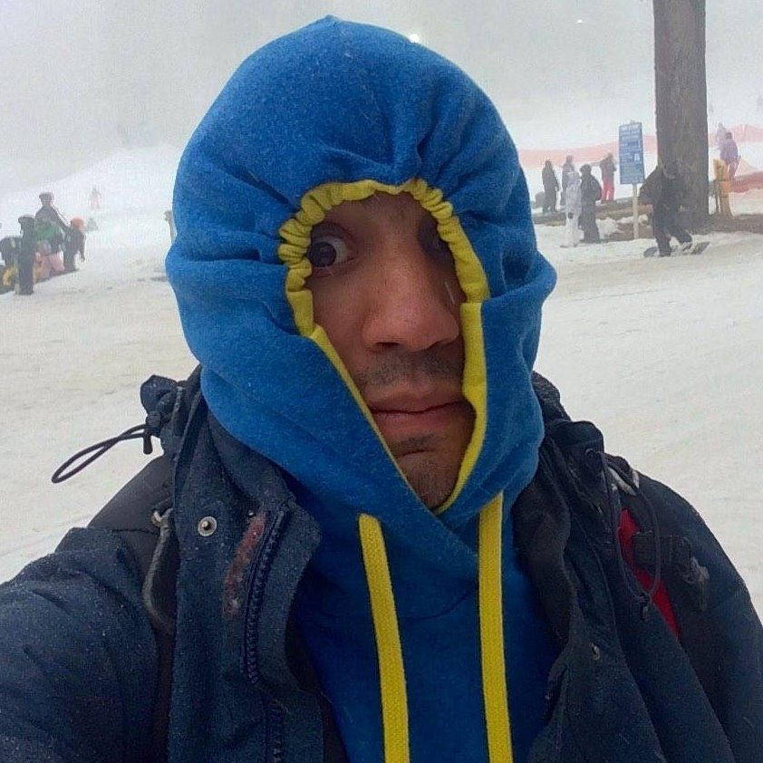

### Content

I am interested in human driven impacts (with special attention to climate change) on fisheries resources in Latin America. How impacts of environmental change affect social structures, such as food security and local economies, how they can be measured, and how to create social adaptive capacity to such changes.

As of today, I’m on my second year of the Master program at the Bren School of Environmental Science & MAnagement. My group proyect looks to develop a Citizen Science program for the rocky intertidal zone

More about our project in: http://intertidalteam.weebly.com

### Techniques

I think that GitHub will be a great tool for mi present and future work. At Bren, I’ve been envolved to coding projects. Learning how to use GitHub will provide me a new tool to organize my group-work.

### Data

I still have no data for my proyect. I Could use some of the FAOStats available data. I would like to address climate change impacts to a certain species or may be a group of.

```r
 # read csv
Data = read.csv("data/jepa_ReefPerch.csv")

# output summary
summary(Data)
```

```
##    SITE       FISHSIZE
##  AQUE:20   Min.   : 5.00
##  MOHK:20   1st Qu.: 8.00
##  NAPL:20   Median :10.00
##            Mean   :10.32
##            3rd Qu.:12.00
##            Max.   :15.00
```

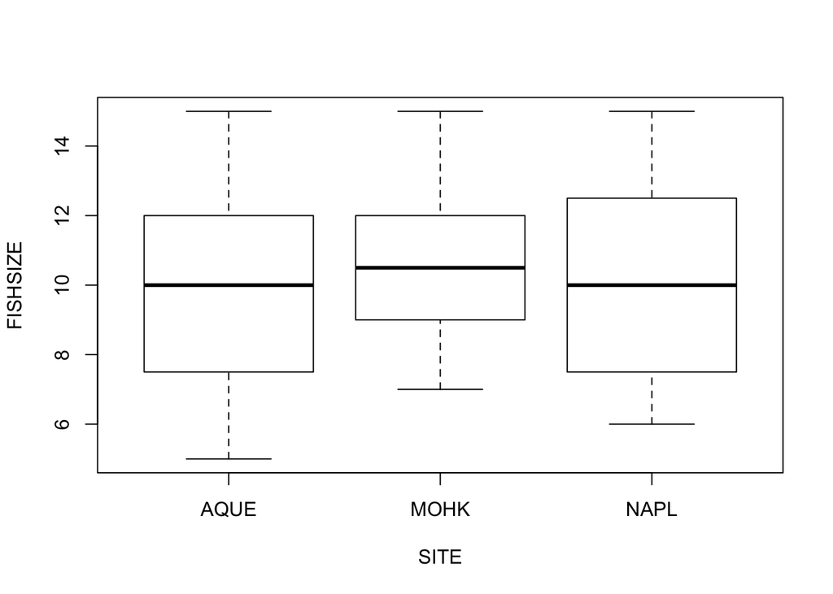

```r
plot(Data)
```

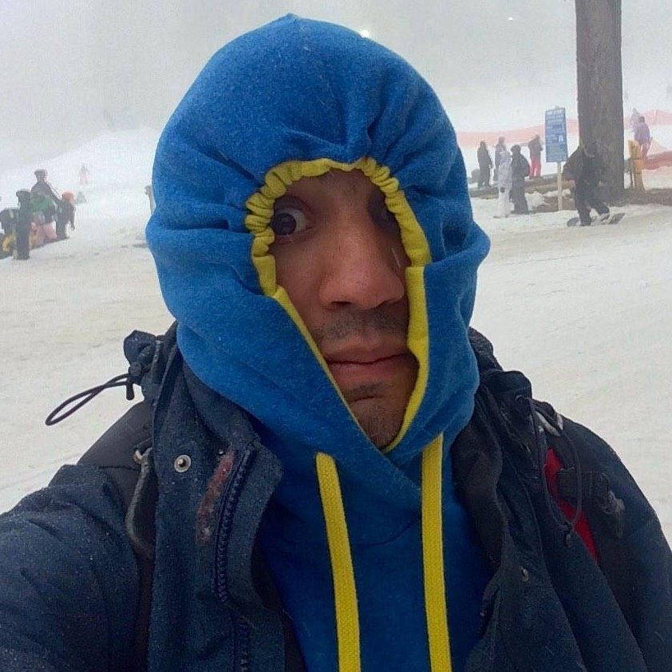

## General Information

### Content

I am interested in human driven impacts (with special attention to climate change) on fisheries resources in Latin America. How impacts of environmental change affect social structures, such as food security and local economies, how they can be measured, and how to create social adaptive capacity to such changes.

As of today, I’m on my second year of the Master program at the Bren School of Environmental Science & MAnagement. My group proyect looks to develop a Citizen Science program for the rocky intertidal zone

More about our project in: http://intertidalteam.weebly.com

### Techniques

I think that GitHub will be a great tool for mi present and future work. At Bren, I’ve been envolved to coding projects. Learning how to use GitHub will provide me a new tool to organize my group-work.

### Data

I still have no data for my proyect. I Could use some of the FAOStats available data. I would like to address climate change impacts to a certain species or may be a group of.

```r
suppressWarnings(library(readr))
suppressWarnings(library(knitr))

 # read csv
Data = read.csv("data/jepa_ReefPerch.csv")

# output summary
summary(Data)
```

```
##    SITE       FISHSIZE
##  AQUE:20   Min.   : 5.00
##  MOHK:20   1st Qu.: 8.00
##  NAPL:20   Median :10.00
##            Mean   :10.32
##            3rd Qu.:12.00
##            Max.   :15.00
```

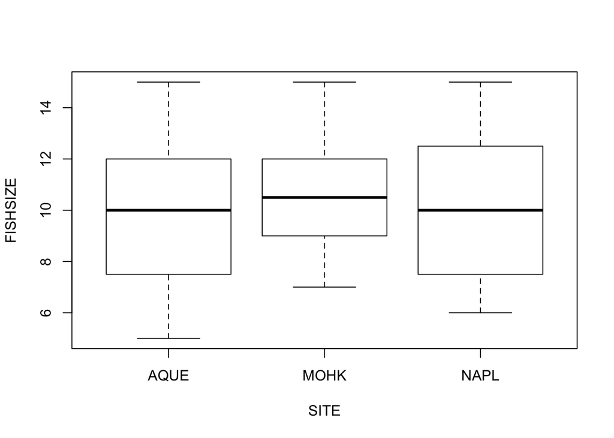

```r
plot(Data)
```

## Asignment Reading and Wrangling

### EDAWR

```r
suppressWarnings(library(EDAWR))
kable(storms)
```

| storm | wind | pressure | date |
| --- | --- | --- | --- |
| Alberto | 110 | 1007 | 2000-08-03 |
| Alex | 45 | 1009 | 1998-07-27 |
| Allison | 65 | 1005 | 1995-06-03 |
| Ana | 40 | 1013 | 1997-06-30 |
| Arlene | 50 | 1010 | 1999-06-11 |
| Arthur | 45 | 1010 | 1996-06-17 |

```r
kable(cases)
```

| country | 2011 | 2012 | 2013 |
| --- | --- | --- | --- |
| FR | 7000 | 6900 | 7000 |
| DE | 5800 | 6000 | 6200 |
| US | 15000 | 14000 | 13000 |

```r
kable(pollution)
```

| city | size | amount |
| --- | --- | --- |
| New York | large | 23 |
| New York | small | 14 |
| London | large | 22 |
| London | small | 16 |
| Beijing | large | 121 |
| Beijing | small | 56 |

```r
ratio <- storms$pressure/storms$wind
```

### Tidyr

```r
suppressWarnings(library(tidyr))
?gather
?spread

k<- gather(cases,"year","n",2:4)
kable(k)
```

| country | year | n |
| --- | --- | --- |
| FR | 2011 | 7000 |
| DE | 2011 | 5800 |
| US | 2011 | 15000 |
| FR | 2012 | 6900 |
| DE | 2012 | 6000 |
| US | 2012 | 14000 |
| FR | 2013 | 7000 |
| DE | 2013 | 6200 |
| US | 2013 | 13000 |

```r
PollutionTable <- spread(pollution,"size","amount")
kable(PollutionTable)
```

| city | large | small |
| --- | --- | --- |
| Beijing | 121 | 56 |
| London | 22 | 16 |
| New York | 23 | 14 |

```r
SepStorms<- separate(storms, date, c("year", "month", "day"), sep = "-")
kable(SepStorms)
```

| storm | wind | pressure | year | month | day |
| --- | --- | --- | --- | --- | --- |
| Alberto | 110 | 1007 | 2000 | 08 | 03 |
| Alex | 45 | 1009 | 1998 | 07 | 27 |
| Allison | 65 | 1005 | 1995 | 06 | 03 |
| Ana | 40 | 1013 | 1997 | 06 | 30 |
| Arlene | 50 | 1010 | 1999 | 06 | 11 |
| Arthur | 45 | 1010 | 1996 | 06 | 17 |

```r
UniteStorms <- unite(SepStorms, "date", year, month, day, sep = "-")
kable(UniteStorms)
```

| storm | wind | pressure | date |
| --- | --- | --- | --- |
| Alberto | 110 | 1007 | 2000-08-03 |
| Alex | 45 | 1009 | 1998-07-27 |
| Allison | 65 | 1005 | 1995-06-03 |
| Ana | 40 | 1013 | 1997-06-30 |
| Arlene | 50 | 1010 | 1999-06-11 |
| Arthur | 45 | 1010 | 1996-06-17 |

### Dplyr

```r
suppressWarnings(library(dplyr))
suppressWarnings(library(nycflights13))

StormPressure<- select(storms, storm,pressure) #selects from "storms" data "storm and pressure"
select(storms,-storm) #sellects all except "storm"
```

```
## Source: local data frame [6 x 3]
##
##    wind pressure       date
##   (int)    (int)     (date)
## 1   110     1007 2000-08-03
## 2    45     1009 1998-07-27
## 3    65     1005 1995-06-03
## 4    40     1013 1997-06-30
## 5    50     1010 1999-06-11
## 6    45     1010 1996-06-17
```

```r
Avion<- select(planes,type:model)
kable(head(Avion))
```

| type | manufacturer | model |
| --- | --- | --- |
| Fixed wing multi engine | EMBRAER | EMB-145XR |
| Fixed wing multi engine | AIRBUS INDUSTRIE | A320-214 |
| Fixed wing multi engine | AIRBUS INDUSTRIE | A320-214 |
| Fixed wing multi engine | AIRBUS INDUSTRIE | A320-214 |
| Fixed wing multi engine | EMBRAER | EMB-145LR |
| Fixed wing multi engine | AIRBUS INDUSTRIE | A320-214 |

```r
filter(Avion,manufacturer == "EMBRAER")
```

```
## Source: local data frame [299 x 3]
##
##                       type manufacturer     model
##                      (chr)        (chr)     (chr)
## 1  Fixed wing multi engine      EMBRAER EMB-145XR
## 2  Fixed wing multi engine      EMBRAER EMB-145LR
## 3  Fixed wing multi engine      EMBRAER EMB-145XR
## 4  Fixed wing multi engine      EMBRAER EMB-145XR
## 5  Fixed wing multi engine      EMBRAER EMB-145XR
## 6  Fixed wing multi engine      EMBRAER EMB-145XR
## 7  Fixed wing multi engine      EMBRAER EMB-145XR
## 8  Fixed wing multi engine      EMBRAER EMB-145XR
## 9  Fixed wing multi engine      EMBRAER EMB-145XR
## 10 Fixed wing multi engine      EMBRAER EMB-145XR
## ..                     ...          ...       ...
```

```r
filter(planes, manufacturer == "EMBRAER", model %in% c("EMB-145XR","EMB-145LR"))
```

```
## Source: local data frame [218 x 9]
##
##    tailnum  year                    type manufacturer     model engines
##      (chr) (int)                   (chr)        (chr)     (chr)   (int)
## 1   N10156  2004 Fixed wing multi engine      EMBRAER EMB-145XR       2
## 2   N10575  2002 Fixed wing multi engine      EMBRAER EMB-145LR       2
## 3   N11106  2002 Fixed wing multi engine      EMBRAER EMB-145XR       2
## 4   N11107  2002 Fixed wing multi engine      EMBRAER EMB-145XR       2
## 5   N11109  2002 Fixed wing multi engine      EMBRAER EMB-145XR       2
## 6   N11113  2002 Fixed wing multi engine      EMBRAER EMB-145XR       2
## 7   N11119  2002 Fixed wing multi engine      EMBRAER EMB-145XR       2
## 8   N11121  2003 Fixed wing multi engine      EMBRAER EMB-145XR       2
## 9   N11127  2003 Fixed wing multi engine      EMBRAER EMB-145XR       2
## 10  N11137  2003 Fixed wing multi engine      EMBRAER EMB-145XR       2
## ..     ...   ...                     ...          ...       ...     ...
## Variables not shown: seats (int), speed (int), engine (chr)
```

```r
Planes2 <- select(planes,manufacturer,engines,seats)
PlanesMut<- mutate(Planes2, PPlPerSeat = seats/engines)
kable(head(PlanesMut))
```

| manufacturer | engines | seats | PPlPerSeat |
| --- | --- | --- | --- |
| EMBRAER | 2 | 55 | 27.5 |
| AIRBUS INDUSTRIE | 2 | 182 | 91.0 |
| AIRBUS INDUSTRIE | 2 | 182 | 91.0 |
| AIRBUS INDUSTRIE | 2 | 182 | 91.0 |
| EMBRAER | 2 | 55 | 27.5 |
| AIRBUS INDUSTRIE | 2 | 182 | 91.0 |

```r
planes %>% summarise(median = median(seats), variance = var(seats),mean=mean(seats),sd=sd(seats),n=n())
```

```
## Source: local data frame [1 x 5]
##
##   median variance     mean       sd     n
##    (dbl)    (dbl)    (dbl)    (dbl) (int)
## 1    149 5425.055 154.3164 73.65497  3322
```

```r
arrange(storms,wind)
```

```
## Source: local data frame [6 x 4]
##
##     storm  wind pressure       date
##     (chr) (int)    (int)     (date)
## 1     Ana    40     1013 1997-06-30
## 2    Alex    45     1009 1998-07-27
## 3  Arthur    45     1010 1996-06-17
## 4  Arlene    50     1010 1999-06-11
## 5 Allison    65     1005 1995-06-03
## 6 Alberto   110     1007 2000-08-03
```

#### The Pipe Operator

```r
select(airports, name,alt)
```

```
## Source: local data frame [1,397 x 2]
##
##                              name   alt
##                             (chr) (int)
## 1               Lansdowne Airport  1044
## 2   Moton Field Municipal Airport   264
## 3             Schaumburg Regional   801
## 4                 Randall Airport   523
## 5           Jekyll Island Airport    11
## 6  Elizabethton Municipal Airport  1593
## 7         Williams County Airport   730
## 8   Finger Lakes Regional Airport   492
## 9    Shoestring Aviation Airfield  1000
## 10          Jefferson County Intl   108
## ..                            ...   ...
```

```r
airports %>% select(name,alt)
```

```
## Source: local data frame [1,397 x 2]
##
##                              name   alt
##                             (chr) (int)
## 1               Lansdowne Airport  1044
## 2   Moton Field Municipal Airport   264
## 3             Schaumburg Regional   801
## 4                 Randall Airport   523
## 5           Jekyll Island Airport    11
## 6  Elizabethton Municipal Airport  1593
## 7         Williams County Airport   730
## 8   Finger Lakes Regional Airport   492
## 9    Shoestring Aviation Airfield  1000
## 10          Jefferson County Intl   108
## ..                            ...   ...
```

```r
A<- airports %>% filter(alt >= 2000)
kable(head(A))
```

| faa | name | lat | lon | alt | tz | dst |
| --- | --- | --- | --- | --- | --- | --- |
| 2G9 | Somerset County Airport | 40.03887 | -79.0150 | 2275 | -5 | A |
| 36U | Heber City Municipal Airport | 40.48181 | -111.4288 | 5637 | -6 | A |
| 4U9 | Dell Flight Strip | 44.73575 | -112.7200 | 6007 | -7 | A |
| 6S0 | Big Timber Airport | 45.80639 | -109.9811 | 4492 | -7 | A |
| ABQ | Albuquerque International Sunport | 35.04022 | -106.6092 | 5355 | -7 | A |
| AIA | Alliance Municipal Airport | 42.05333 | -102.8039 | 3931 | -7 | A |

### Unit of Analysis

```r
pollution %>% group_by(city) %>% summarise(mean = mean(amount), sum = sum(amount), n = n())
```

```
## Source: local data frame [3 x 4]
##
##       city  mean   sum     n
##      (chr) (dbl) (dbl) (int)
## 1  Beijing  88.5   177     2
## 2   London  19.0    38     2
## 3 New York  18.5    37     2
```

```r
planes %>% group_by(manufacturer) %>% summarise(mean=mean(seats),sd=sd(seats),n=n())
```

```
## Source: local data frame [35 x 4]
##
##              manufacturer     mean         sd     n
##                     (chr)    (dbl)      (dbl) (int)
## 1              AGUSTA SPA   8.0000         NA     1
## 2                  AIRBUS 221.2024 81.4309017   336
## 3        AIRBUS INDUSTRIE 187.4025 23.8565154   400
## 4   AMERICAN AIRCRAFT INC   2.0000  0.0000000     2
## 5      AVIAT AIRCRAFT INC   2.0000         NA     1
## 6  AVIONS MARCEL DASSAULT  12.0000         NA     1
## 7           BARKER JACK L   2.0000         NA     1
## 8                   BEECH   9.5000  0.7071068     2
## 9                    BELL   8.0000  4.2426407     2
## 10                 BOEING 175.1877 59.4688097  1630
## ..                    ...      ...        ...   ...
```

### Joining Data

```r
Colors<-bind_cols(y,z)
kable(Colors)
```

| x1 | x2 | x1 | x2 |
| --- | --- | --- | --- |
| A | 1 | B | 2 |
| B | 2 | C | 3 |
| C | 3 | D | 4 |

```r
kable(Colors)
```

| x1 | x2 | x1 | x2 |
| --- | --- | --- | --- |
| A | 1 | B | 2 |
| B | 2 | C | 3 |
| C | 3 | D | 4 |

```r
Cr<- bind_rows(y, z)
kable(Cr)
```

| x1 | x2 |
| --- | --- |
| A | 1 |
| B | 2 |
| C | 3 |
| B | 2 |
| C | 3 |
| D | 4 |

```r
Un<-union(y, z)
kable(Un)
```

| x1 | x2 |
| --- | --- |
| D | 4 |
| C | 3 |
| B | 2 |
| A | 1 |

```r
In<-intersect(y, z)
kable(In)
```

| x1 | x2 |
| --- | --- |
| B | 2 |
| C | 3 |

```r
Set<-setdiff(y, z)
kable(Set)
```

| x1 | x2 |
| --- | --- |
| A | 1 |

```r
AName <- left_join(songs, artists, by = "name")
kable(AName)
```

| song | name | plays |
| --- | --- | --- |
| Across the Universe | John | guitar |
| Come Together | John | guitar |
| Hello, Goodbye | Paul | bass |
| Peggy Sue | Buddy | NA |

```r
LFL<- left_join(songs2, artists2, by = c("first", "last"))
kable(LFL)
```

| song | first | last | plays |
| --- | --- | --- | --- |
| Across the Universe | John | Lennon | guitar |
| Come Together | John | Lennon | guitar |
| Hello, Goodbye | Paul | McCartney | bass |
| Peggy Sue | Buddy | Holly | NA |

```r
InnerN<- inner_join(songs, artists, by = "name")
kable(InnerN)
```

| song | name | plays |
| --- | --- | --- |
| Across the Universe | John | guitar |
| Come Together | John | guitar |
| Hello, Goodbye | Paul | bass |

```r
SemNa<- semi_join(songs, artists, by = "name")
kable(SemNa)
```

| song | name |
| --- | --- |
| Across the Universe | John |
| Come Together | John |
| Hello, Goodbye | Paul |

```r
AJ<-anti_join(songs, artists, by = "name")
kable(AJ)
```

| song | name |
| --- | --- |
| Peggy Sue | Buddy |